# WB-XAI-2 - praca domowa 2

Mateusz Grzyb

[figure not shown]

## Wczytanie i wstępna obróbka danych

```r
library(OpenML)

blood <- getOMLDataSet(data.id = 1464)
blood <- blood$data

head(blood)
```

|  | V1 | V2 | V3 | V4 | Class |
| --- | --- | --- | --- | --- | --- |
| 0 | 2 | 50 | 12500 | 98 | 2 |
| 1 | 0 | 13 | 3250 | 28 | 2 |
| 2 | 1 | 16 | 4000 | 35 | 2 |
| 3 | 2 | 20 | 5000 | 45 | 2 |
| 4 | 1 | 24 | 6000 | 77 | 1 |
| 5 | 4 | 4 | 1000 | 4 | 1 |

Podobnie jak ostatnio - modyfikujemy nazwy predyktorów oraz poziomy zmiennej celu.

```r
row.names(blood) <- NULL
names(blood) <- c('Recency', 'Frequency', 'Monetary', 'Time', 'Donated')
blood$Donated <- factor(ifelse(blood$Donated==2, 1, 0))

head(blood)
```

|  | Recency | Frequency | Monetary | Time | Donated |
| --- | --- | --- | --- | --- | --- |
| 1 | 2 | 50 | 12500 | 98 | 1 |
| 2 | 0 | 13 | 3250 | 28 | 1 |
| 3 | 1 | 16 | 4000 | 35 | 1 |
| 4 | 2 | 20 | 5000 | 45 | 1 |
| 5 | 1 | 24 | 6000 | 77 | 0 |
| 6 | 4 | 4 | 1000 | 4 | 0 |

Ponadto, pozbędziemy się kolumny Monetary, ponieważ poprzednio pokazaliśmy, że ma ona taki sam rozkład jak zmienna Frequency (z dokładnością do skali.)

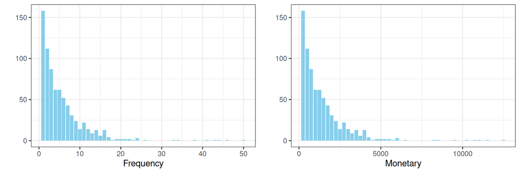

```r
library(ggplot2)
library(gridExtra)

variables <- c('Frequency', 'Monetary')

plots <- lapply(variables, function(variable){
  ggplot(data=blood, aes_string(variable)) +
    geom_bar(fill='skyblue') +
    ylab('') +
    theme_bw()
})

grid.arrange(grobs=plots, nrow=1)
```

```r
blood <- blood[-3]

head(blood)
```

|  | Recency | Frequency | Time | Donated |
| --- | --- | --- | --- | --- |
| 1 | 2 | 50 | 98 | 1 |
| 2 | 0 | 13 | 28 | 1 |
| 3 | 1 | 16 | 35 | 1 |
| 4 | 2 | 20 | 45 | 1 |
| 5 | 1 | 24 | 77 | 0 |
| 6 | 4 | 4 | 4 | 0 |

## Kłopotliwa korelacja zmiennych

Podczas prezentacji EDA zbioru pokazaliśmy, że występuje znaczna korelacja zmiennych Frequency i Time.

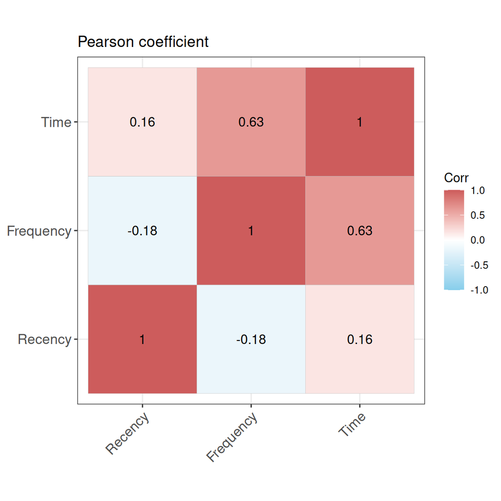

```r
library(ggcorrplot)

corr <- round(cor(blood[-4], method='pearson'), 2)
ggcorrplot(corr, lab=TRUE, title='Pearson coefficient',
           ggtheme=ggplot2::theme_bw, colors = c('skyblue', 'white', 'indianred'))
```

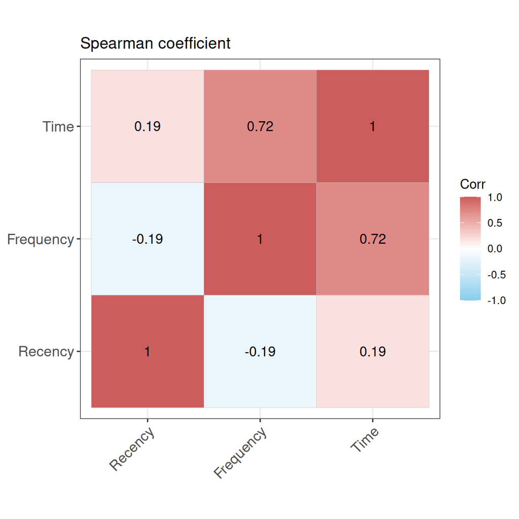

```r
corr <- round(cor(blood[-4], method='spearman'), 2)
ggcorrplot(corr, lab=TRUE, title='Spearman coefficient',
           ggtheme=ggplot2::theme_bw, colors = c('skyblue', 'white', 'indianred'))
```

Chcemy:

- zmniejszyć występujące w danych korelacje,
- zachować interpretowalność zmiennych,
- nie utracić zupełnie informacji niesionej przez poszczególne zmienne.

W tym celu testujemy następującą transformację:

```r
blood_m <- cbind(
  blood[c('Recency', 'Frequency')],
  Intensity=blood$Frequency/pmax(blood$Time-blood$Recency, 1),
  blood['Donated'])

head(blood_m)
```

|  | Recency | Frequency | Intensity | Donated |
| --- | --- | --- | --- | --- |
| 1 | 2 | 50 | 0.5208333 | 1 |
| 2 | 0 | 13 | 0.4642857 | 1 |
| 3 | 1 | 16 | 0.4705882 | 1 |
| 4 | 2 | 20 | 0.4651163 | 1 |
| 5 | 1 | 24 | 0.3157895 | 0 |
| 6 | 4 | 4 | 4.0000000 | 0 |

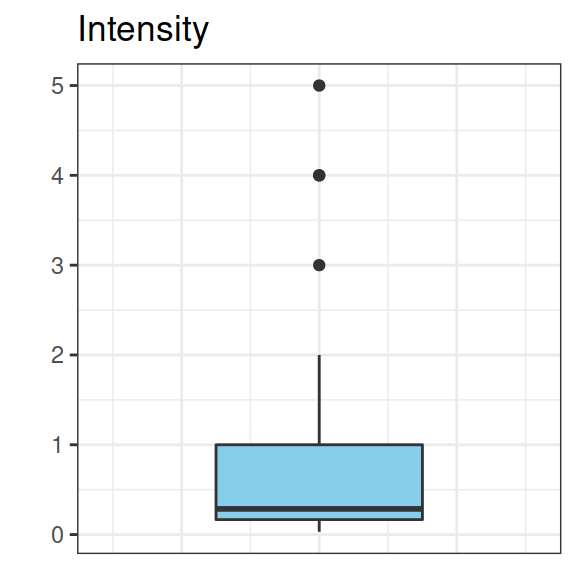

```r
ggplot(data=blood_m, aes(y=Intensity)) +
  geom_boxplot(fill='skyblue') +
  xlim(c(-0.8, 0.8)) +
  xlab('') +
  ylab('') +
  labs(title='Intensity') +
  theme_bw() +
  theme(
    axis.title.x=element_blank(),
    axis.text.x=element_blank(),
    axis.ticks.x=element_blank()
  )
```

Nowa zmienna Intensity to liczba donacji dokonanych przez daną osobę podzielona przez Time-Recency, czyli okno czasowe, w którym dana osoba oddawała krew.

Można o niej myśleć jako o wpsółczynniku obecności liczonym dla danej osoby w czasie, kiedy była ona oddawaniem krwi zainteresowana.

Nie jest to zatem współczynnik pozbawiony sensu.

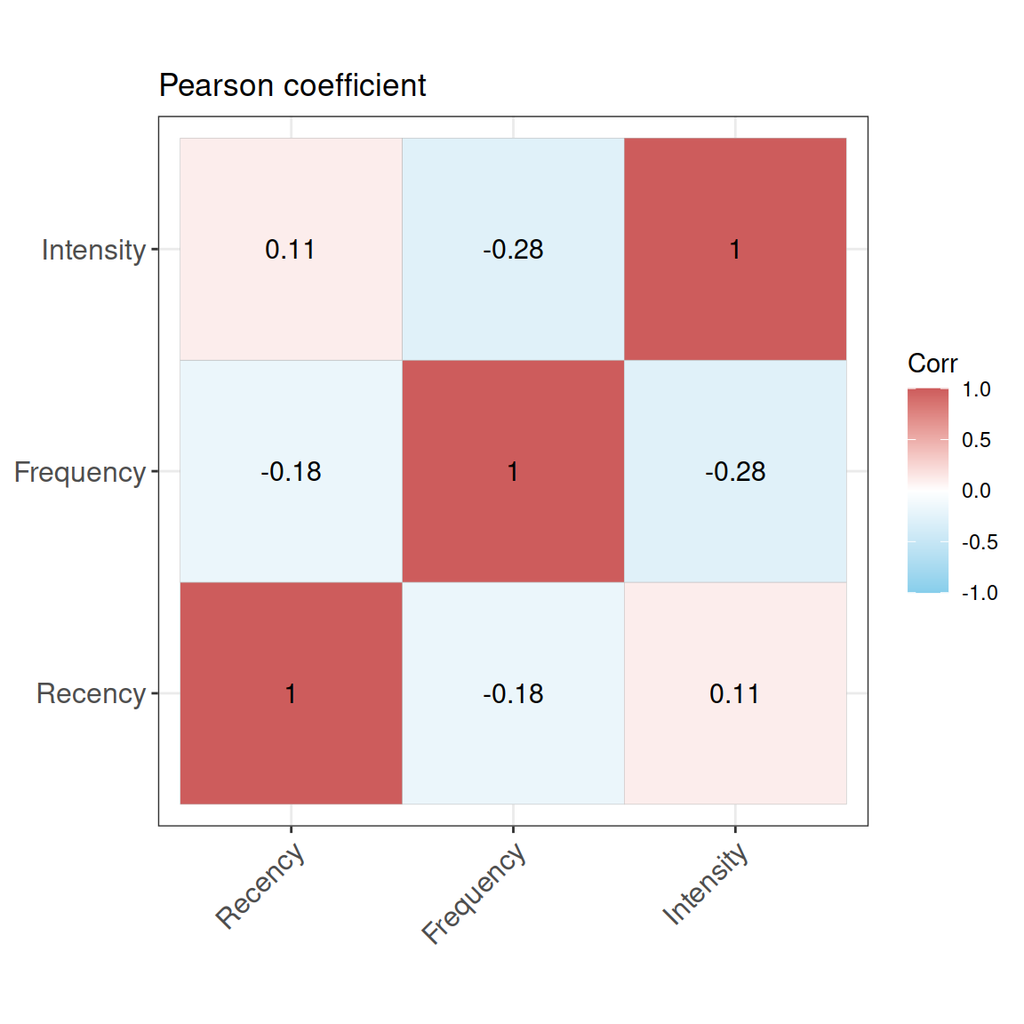

```r
corr <- round(cor(blood_m[-4], method='pearson'), 2)
ggcorrplot(corr, lab=TRUE, title='Pearson coefficient',
           ggtheme=ggplot2::theme_bw, colors = c('skyblue', 'white', 'indianred'))
```

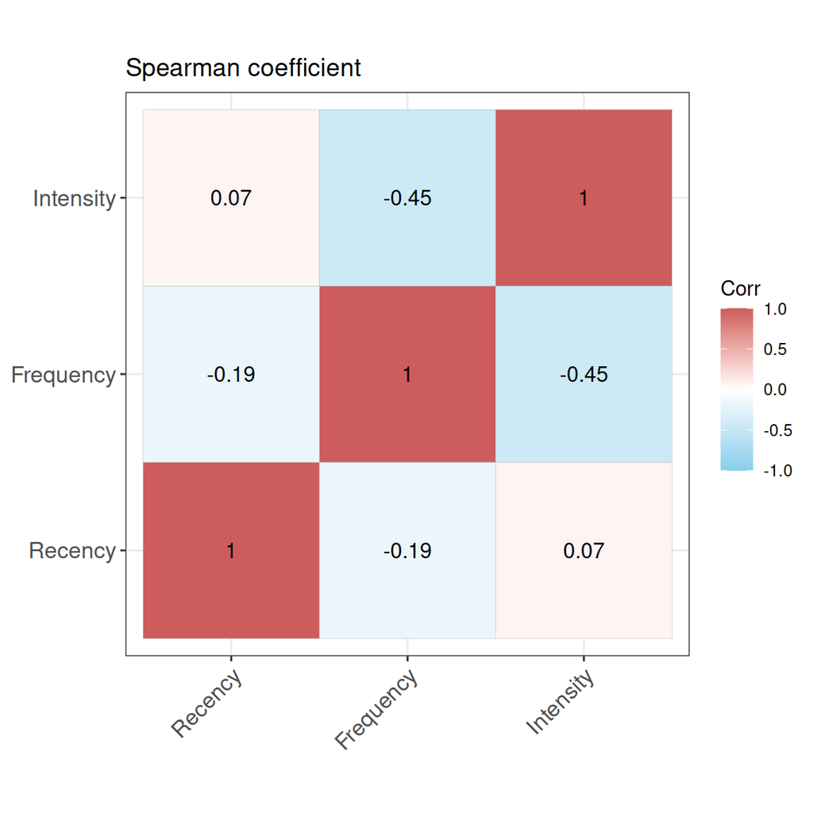

```r
corr <- round(cor(blood_m[-4], method='spearman'), 2)
ggcorrplot(corr, lab=TRUE, title='Spearman coefficient',
           ggtheme=ggplot2::theme_bw, colors = c('skyblue', 'white', 'indianred'))
```

Jak widać udało nam się zniwelować nieco korelacje.

Pozostaje jeszcze jedno pytanie - jaki wpływ będzie miało to na model?

## Przygotowanie modelu

Poniżej testujemy cztery modele:

- na bazie zmiennych Recency, Frequency i Time (model 1),
- na bazie zmiennych Recency i Time (model 2),
- na bazie zmiennych Recency i Frequency (model 3),
- na bazie zmiennych Recency, Frequency i Intensity (model 4).

### Model 1

```r
library(mlr)
library(PRROC)

classif_task1 <- makeClassifTask(id='blood1', data=blood, target='Donated')
classif_lrn1 <- makeLearner('classif.ranger', predict.type='prob')

model1 <- train(classif_lrn1, classif_task1)

pred1 <- predict(model1, classif_task1)$data$prob.1

fg1 <- pred1[blood$Donated==1]
bg1 <- pred1[blood$Donated==0]

roc1 <- roc.curve(scores.class0=fg1, scores.class1=bg1, curve=T)
pr1 <- pr.curve(scores.class0=fg1, scores.class1=bg1, curve=T)
```

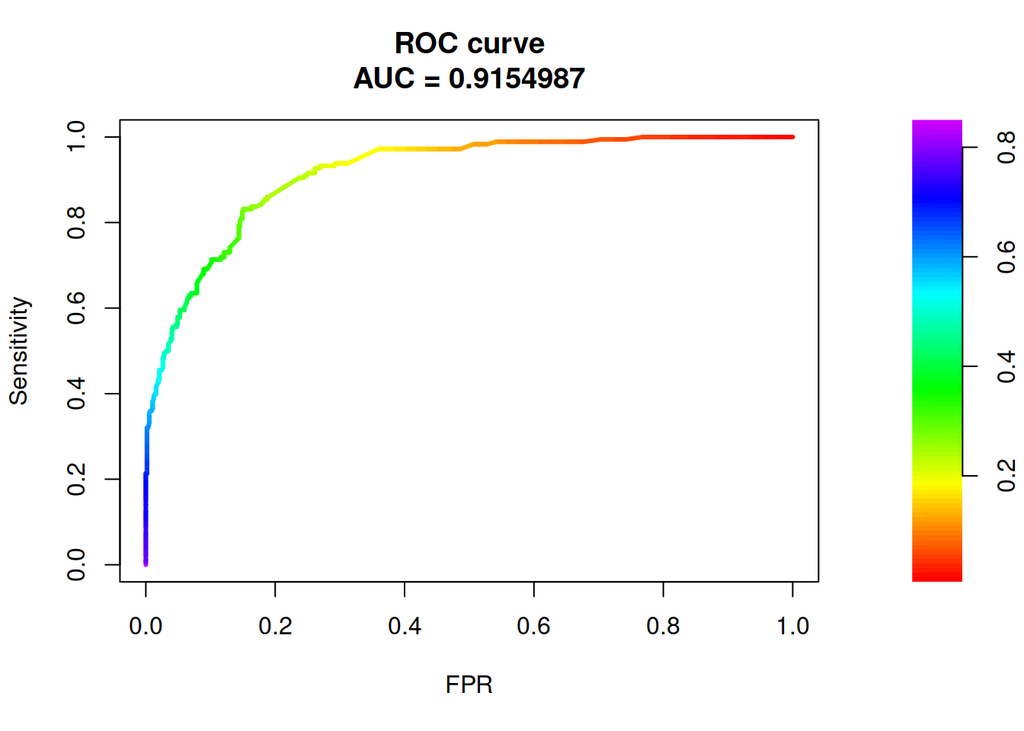

```r
plot(roc1)
```

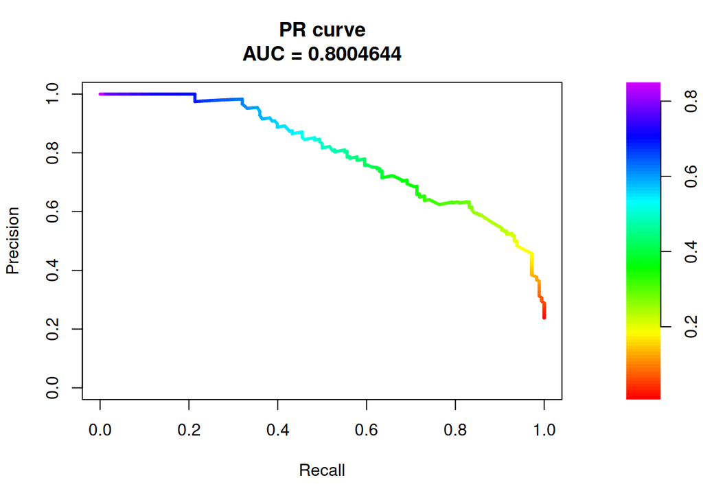

```r
plot(pr1)
```

### Model 2

```r
classif_task2 <- makeClassifTask(id='blood2', data=blood[-2], target='Donated')
classif_lrn2 <- makeLearner('classif.ranger', predict.type='prob')

model2 <- train(classif_lrn2, classif_task2)

pred2 <- predict(model2, classif_task2)$data$prob.1

fg2 <- pred2[blood$Donated==1]
bg2 <- pred2[blood$Donated==0]

roc2 <- roc.curve(scores.class0=fg2, scores.class1=bg2, curve=T)
pr2 <- pr.curve(scores.class0=fg2, scores.class1=bg2, curve=T)
```

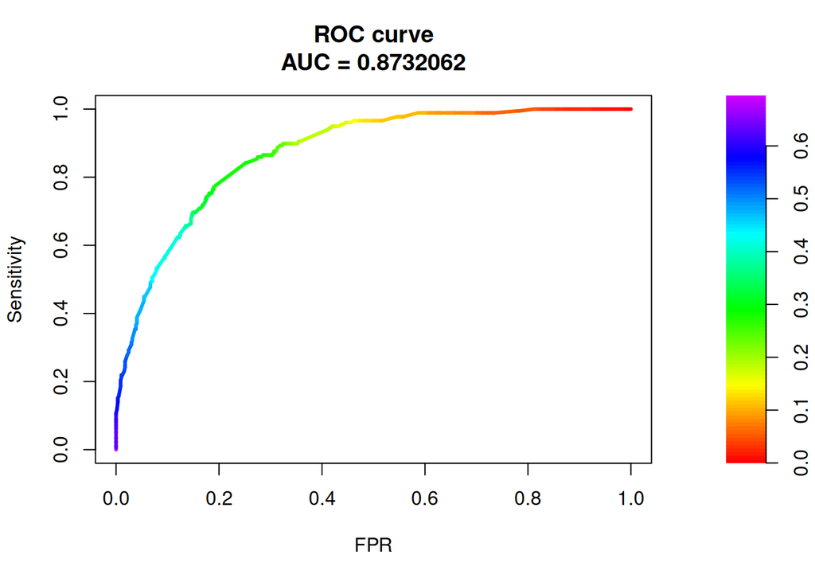

```r
plot(roc2)
```

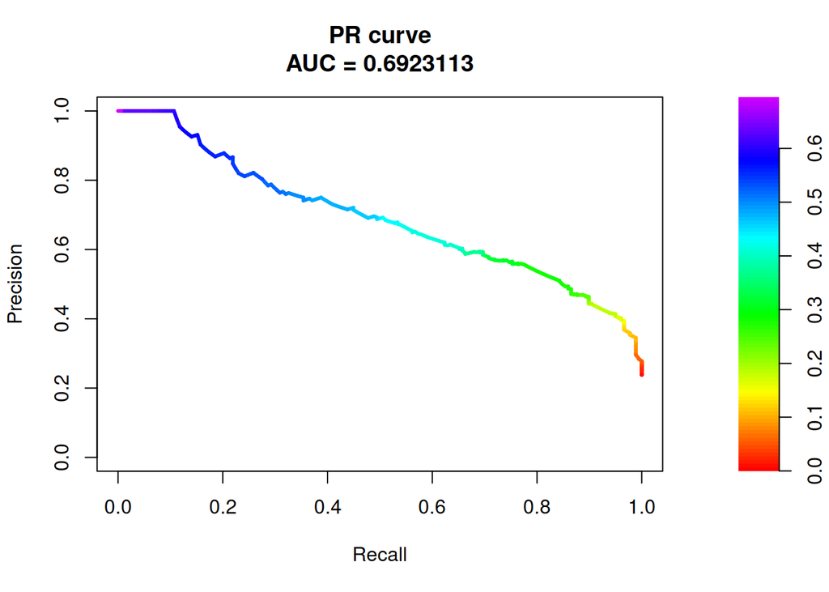

```r
plot(pr2)
```

### Model 3

```r
classif_task3 <- makeClassifTask(id='blood3', data=blood[-3], target='Donated')
classif_lrn3 <- makeLearner('classif.ranger', predict.type='prob')

model3 <- train(classif_lrn3, classif_task3)

pred3 <- predict(model3, classif_task3)$data$prob.1

fg3 <- pred3[blood$Donated==1]
bg3 <- pred3[blood$Donated==0]

roc3 <- roc.curve(scores.class0=fg3, scores.class1=bg3, curve=T)
pr3 <- pr.curve(scores.class0=fg3, scores.class1=bg3, curve=T)
```

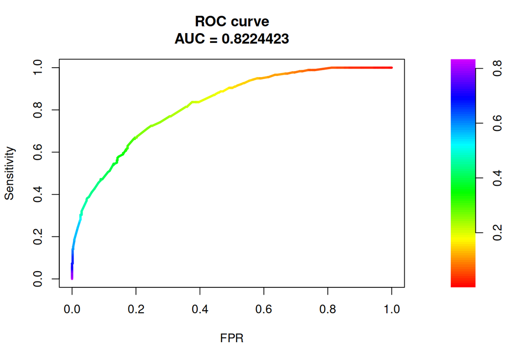

```r
plot(roc3)
```

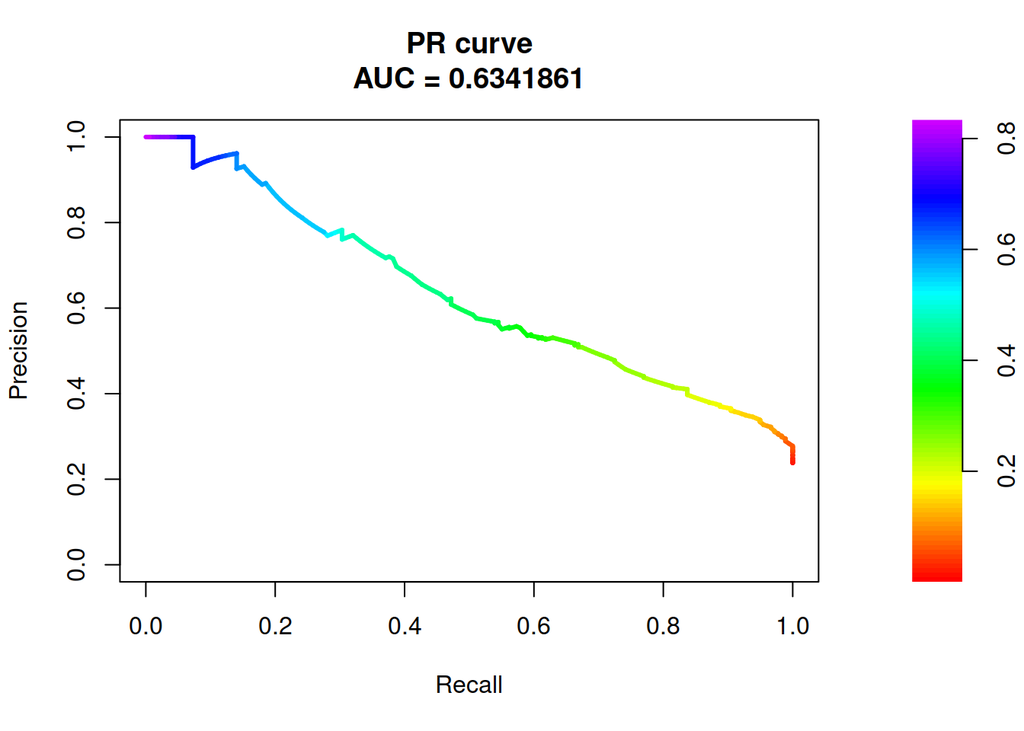

```r
plot(pr3)
```

### Model 4

W tym modelu stosuję dodatkowo poprawkę wag, którą proponuje [ten artykuł](https://towardsdatascience.com/background-d5f101e00afc).

Poprawka ta ma marginalnie pozytywny wpływ na jakość modelu i jej efekt nie zaciemnia wpływu doboru i transformacji zmiennych na wynik.

```r
corr <- round(cor(blood_m[-4], method='spearman'), 2)
c2 <- apply(corr, 1, FUN=function(x) {sum(x^2)})
c2 <- c2/sum(c2)

classif_task4 <- makeClassifTask(id='blood4', data=blood_m, target='Donated')
classif_lrn4 <- makeLearner('classif.ranger', predict.type='prob', split.select.weights=c2)

model4 <- train(classif_lrn4, classif_task4)

pred4 <- predict(model4, classif_task4)$data$prob.1

fg4 <- pred4[blood$Donated==1]
bg4 <- pred4[blood$Donated==0]

roc4 <- roc.curve(scores.class0=fg4, scores.class1=bg4, curve=T)
pr4 <- pr.curve(scores.class0=fg4, scores.class1=bg4, curve=T)
```

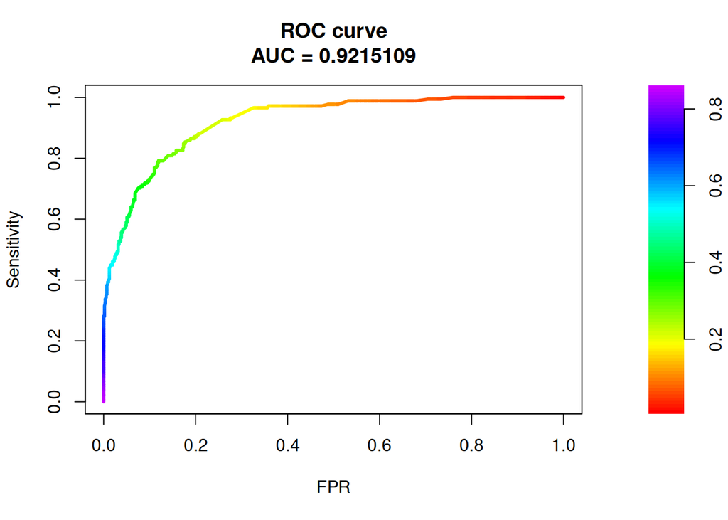

```r
plot(roc4)
```

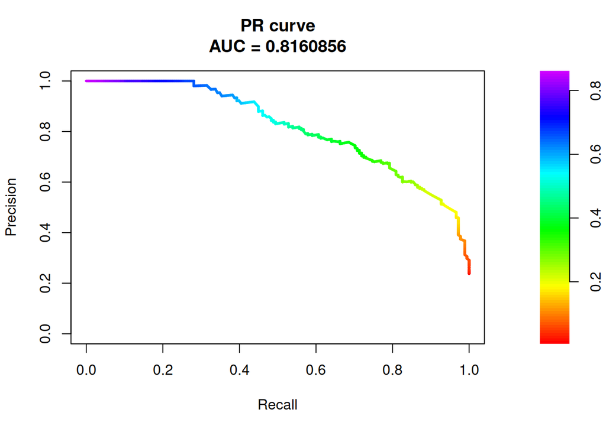

```r
plot(pr4)
```

### Podsumowanie

Po pierwsze - od razu widać, że usuwanie jednej z silnie skorelowanych zmiennych ma negatywny wpływ na jakoś modelu (modele 2 i 3).

Po drugie - model używający wprowadzonej zmiennej Intensity (model 4) jest marginalnie lepszy od modelu używającego oryginalnej zmiennej Time (model 1).

Do dalszych działań wybieramy model 4.

## Właściwa część pracy domowej

Stwórzmy najpierw instancję explainera.

```r
library(DALEX)
library(DALEXtra)

explainer <- explain(model=model4, data=blood_m, y=as.numeric(blood$Donated), label='mlr.ranger', colorize=FALSE)
```

```
## Preparation of a new explainer is initiated
##   -> model label       :  mlr.ranger
##   -> data              :  748  rows  4  cols
##   -> target variable   :  748  values
##   -> predict function  :  yhat.WrappedModel  will be used (  default  )
##   -> predicted values  :  No value for predict function target column. (  default  )
##   -> model_info        :  package mlr , ver. 2.19.0 , task classification (  default  )
##   -> predicted values  :  numerical, min =  0.00953886 , mean =  0.2384921 , max =  0.857306
##   -> residual function :  difference between y and yhat (  default  )
##   -> residuals         :  numerical, min =  0.3451324 , mean =  0.9994758 , max =  1.93589
##   A new explainer has been created!
```

Poniżej znajdują się rozwiązania poszczególnych podpunktów pracy domowej.

“Dla wybranej obserwacji ze zbioru danych wylicz predykcję modelu.”

```r
obs <- blood_m[13, ]
pred <- predict(model4, newdata=obs)
pred$data
```

|  | truth | prob.0 | prob.1 | response |
| --- | --- | --- | --- | --- |
| 13 | 1 | 0.2088586 | 0.7911414 | 1 |

Model poprawnie przewidział odpowiedź dla obserwacji numer 13.

“Dla wybranej obserwacji z punktu 1., wylicz dekompozycję predykcji modelu używając LIME (pakiety w R: live, lime, localModel, iml, pakiety w Python: lime, dalex).”

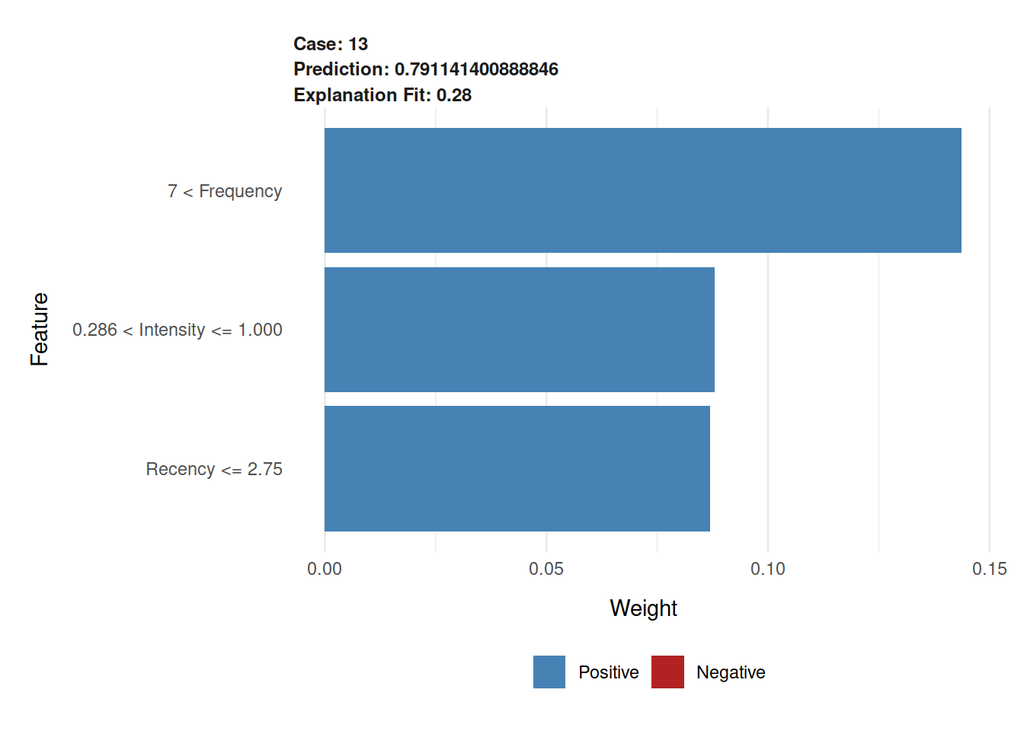

```r
library(lime)

model_type.dalex_explainer <- DALEXtra::model_type.dalex_explainer
predict_model.dalex_explainer <- DALEXtra::predict_model.dalex_explainer

lime_13 <- predict_surrogate(
  explainer=explainer,
  new_observation=blood_m[13, ],
  n_features=3,
  n_permutations=1000,
  type='lime')

plot(lime_13)
```

Podobnie, jak tydzień temu wykazały metody Break Down i Shapley, to, że osoba skrywająca się za obserwacją numer 13 oddawała krew już 10 razy oraz ostatni raz zrobiła to 2 miesiące temu, wpływa korzystnie na prawdopodobnieństwo kolejnego oddania krwi.

Ponadto, korzystny wpływ ma również dosyć wysoka wartość nowej zmiennej Intensity.

“Porównaj dekompozycję LIME dla różnych obserwacji w zbiorze. Jak stabilne są otrzymane wyjaśnienia?”

Wybierzmy po trzy osoby z każdej grupy.

```r
blood_m[c(1, 2, 3), ]
```

|  | Recency | Frequency | Intensity | Donated |
| --- | --- | --- | --- | --- |
| 1 | 2 | 50 | 0.5208333 | 1 |
| 2 | 0 | 13 | 0.4642857 | 1 |
| 3 | 1 | 16 | 0.4705882 | 1 |

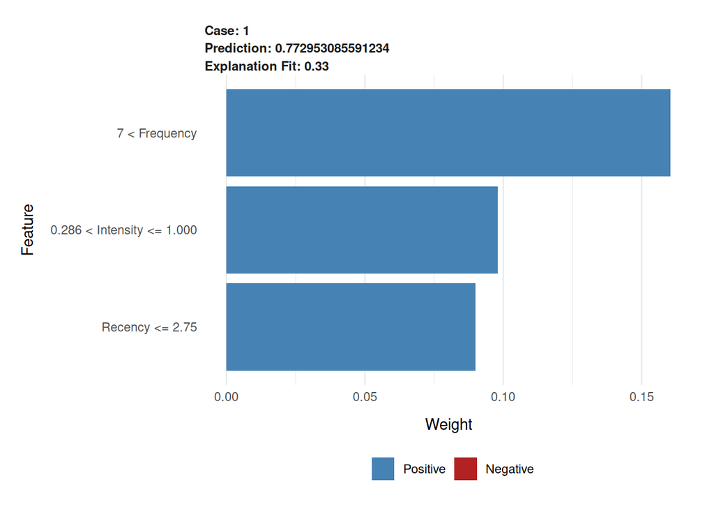

```r
lime_1 <- predict_surrogate(
  explainer=explainer,
  new_observation=blood_m[1, ],
  n_features=3,
  n_permutations=1000,
  type='lime')

plot(lime_1)
```

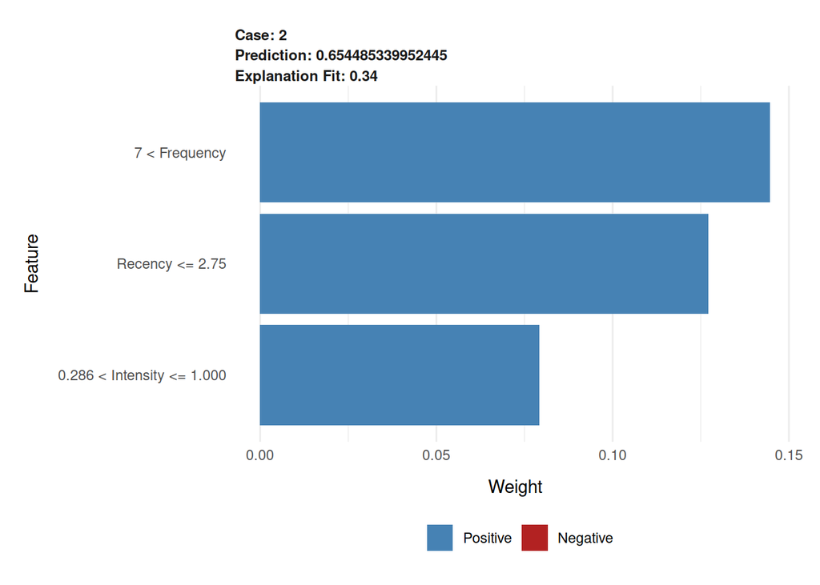

```r
lime_2 <- predict_surrogate(
  explainer=explainer,
  new_observation=blood_m[2, ],
  n_features=3,
  n_permutations=1000,
  type='lime')

plot(lime_2)
```

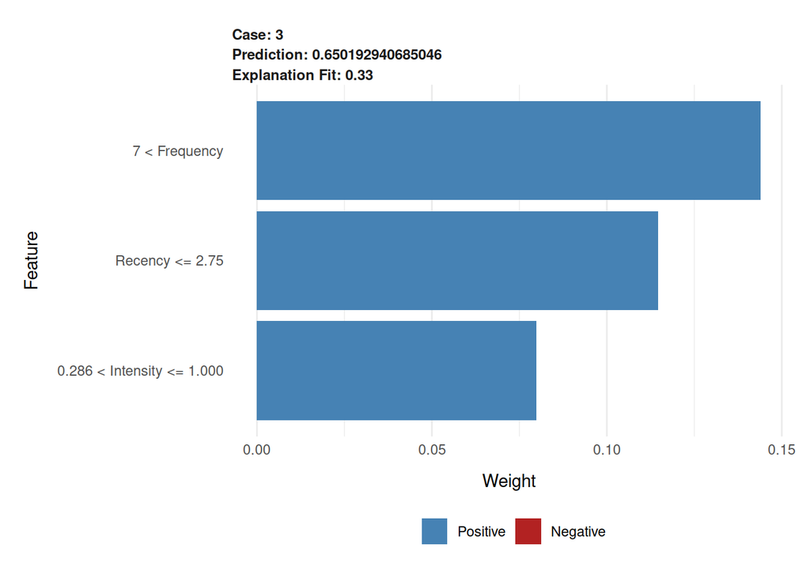

```r
lime_3 <- predict_surrogate(
  explainer=explainer,
  new_observation=blood_m[3, ],
  n_features=3,
  n_permutations=1000,
  type='lime')

plot(lime_3)
```

```r
blood_m[c(270, 271, 272), ]
```

|  | Recency | Frequency | Intensity | Donated |
| --- | --- | --- | --- | --- |
| 270 | 13 | 4 | 0.5000000 | 0 |
| 271 | 16 | 11 | 0.4583333 | 0 |
| 272 | 16 | 7 | 0.5833333 | 0 |

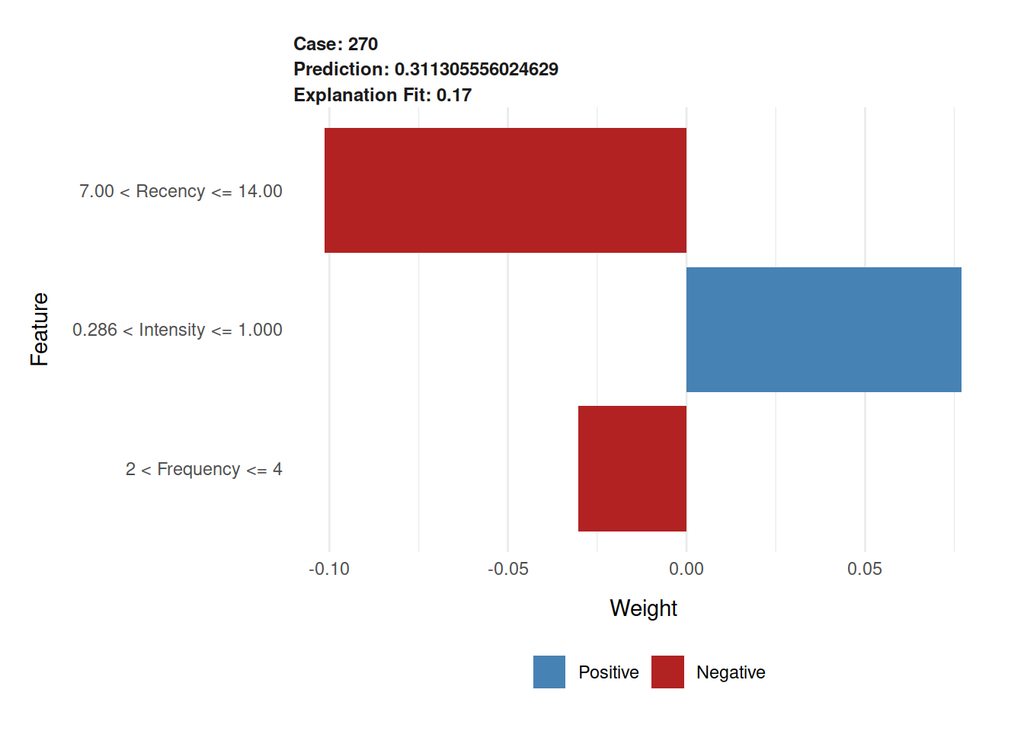

```r
lime_270 <- predict_surrogate(
  explainer=explainer,
  new_observation=blood_m[270, ],
  n_features=3,
  n_permutations=1000,
  type='lime')

plot(lime_270)
```

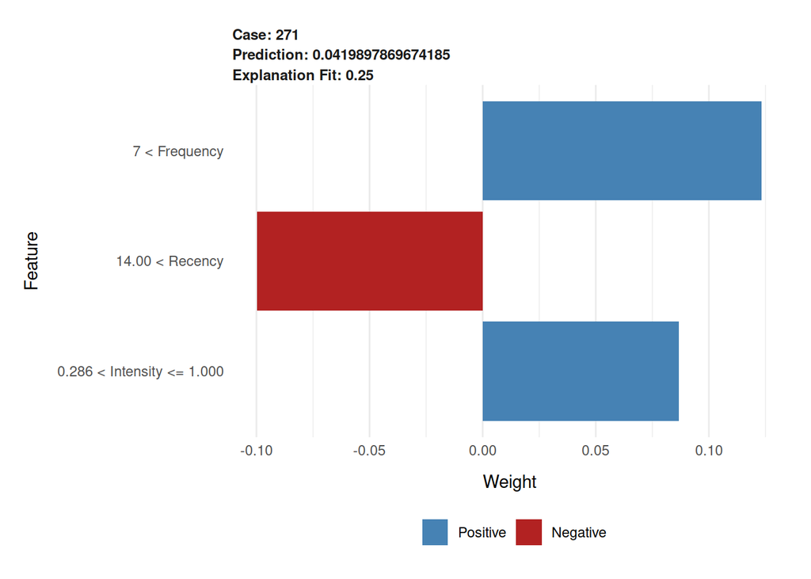

```r
lime_271 <- predict_surrogate(
  explainer=explainer,
  new_observation=blood_m[271, ],
  n_features=3,
  n_permutations=1000,
  type='lime')

plot(lime_271)
```

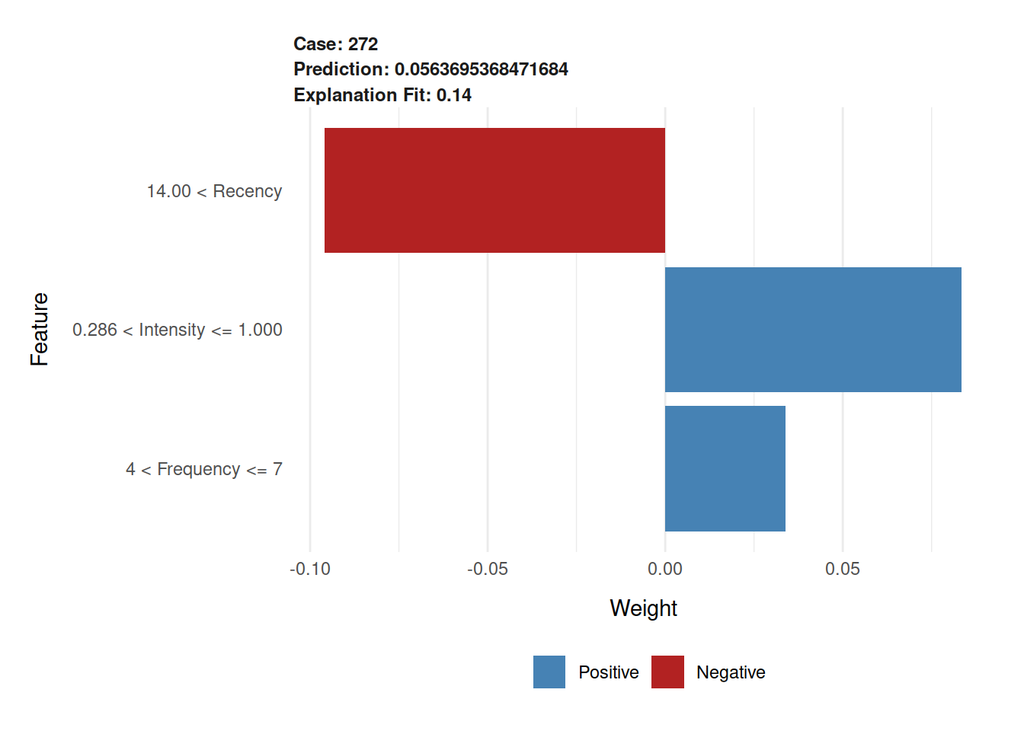

```r
lime_272 <- predict_surrogate(
  explainer=explainer,
  new_observation=blood_m[272, ],
  n_features=3,
  n_permutations=1000,
  type='lime')

plot(lime_272)
```

W tym przypadku otrzymane wyjaśnienia wydają się dosyć stabilne.

Pierwsze trzy obserwacje to wręcz modelowe przykłady - niskie Recency, wysokie Frequency i Intensity. Dla każdej z nich wyjaśnienie przypisuje pozytywny wpływ wszystkim cechom.

Druga trójka to obserwacje opisujące osoby, które nie wróciły w marcu 2007 roku, ale posiadały pewne cechy pozytywne. I tak:

- dla obserwacji 270 dosyć wysokie Intensity również otrzymało dodatni współczynnik, ale przeważył negatywny wpływ wysokiego Recency i niskiego Frequency,
- dla obserwacji 271 dosyć wysokie Intensity i Frequency również otrzymało dodatnie współczynniki, ale przeważył negatywny wpływ wysokiego Recency,
- dla obserwacji 272 stało się to samo co dla obserwacji 271, ale kolejność zmiennych na wykresie zmieniła się - prawdopodobnie dlatego, że Frequency wynosi tutaj 7, a nie 11.

“Dla wybranej obserwacji porównaj wyjaśnienie LIME wyjaśnieniem BreakDown lub SHAP.”

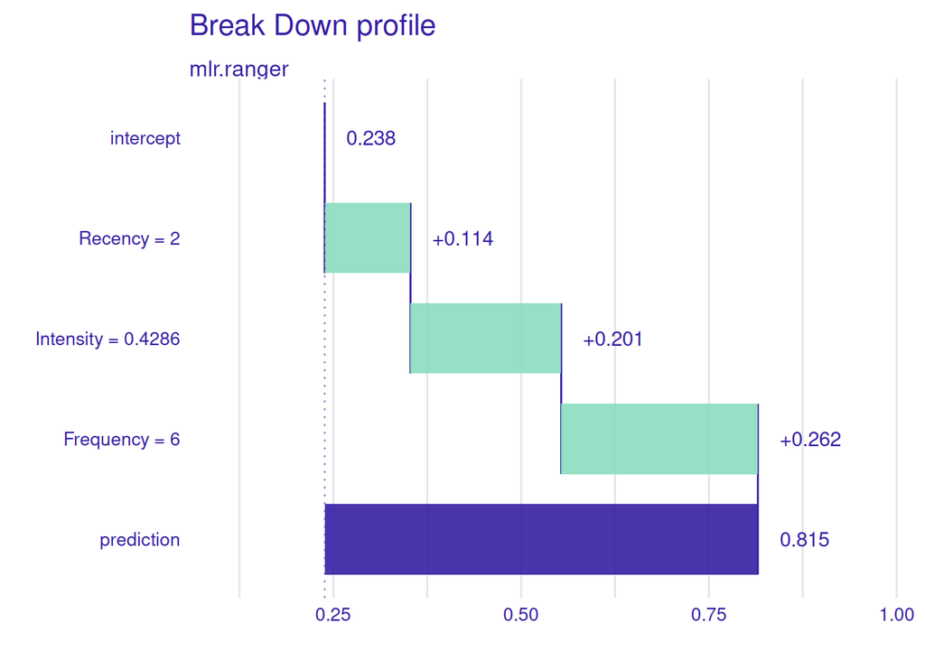

```r
bd23 <- predict_parts(explainer, new_observation=blood_m[23, 1:3])

plot(bd23)
```

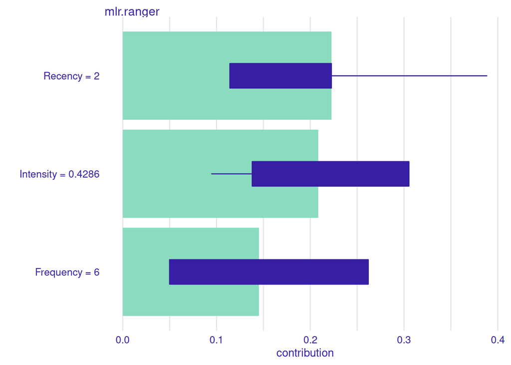

```r
sh23 <- predict_parts(explainer, new_observation=blood_m[23, 1:3], type='shap')

plot(sh23)
```

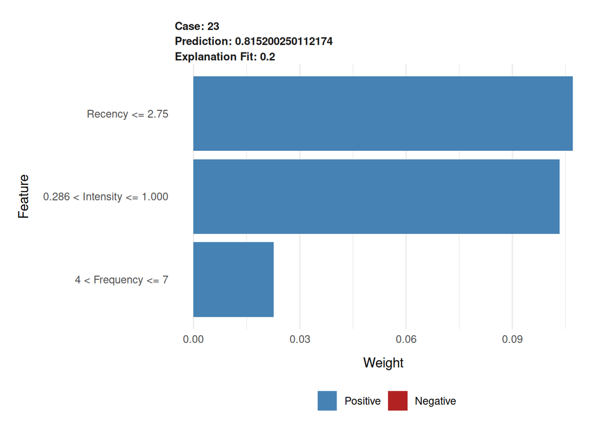

```r
lime_23 <- predict_surrogate(
  explainer=explainer,
  new_observation=blood_m[23, ],
  n_features=3,
  n_permutations=1000,
  type='lime')

plot(lime_23)
```